# Practical Machine Learning assignment Writeup

Ayushi Mehrotra

21/10/2020

# Introduction

The aim of the final project for the Practical Machine Learning course is to verify whether it is possible to understand whether the exercises were conducted correctly from the data provided by devices such as Jawbone Up and Fitbit.

The steps to follow to complete an analysis of this kind were outlined in the course and they are: query, data input, characteristics, algorithm, parameters and assessment; so I will follow this sequence for my task, but not point by point.

### Retrive and cleaning Data

So, loading all the library needed and then retrieving the data is the first thing. This original source is the data for this project: http:/groupware.les.inf.puc-rio.br / har.

```r
library(data.table)
library(mlbench)
library(caret)
library(klaR)
library(randomForest)
library(rattle)
```

```r
library(rpart)
library(rpart.plot)
```

The training data for this project are available here: https://d396qusza40orc.cloudfront.net/predmachlearn/pml-training.csv

The test data are available here: https://d396qusza40orc.cloudfront.net/predmachlearn/pml-testing.csv

I don’t need to download the data in my pc, I can load them to memory.

```r
TrainingData <- fread("https://d396qusza40orc.cloudfront.net/predmachlearn/pml-training.csv", header=T, na.strings=c("NA","#DIV/0!",""))
TestingData <- fread("http://d396qusza40orc.cloudfront.net/predmachlearn/pml-testing.csv", header=T, na.strings=c("NA","#DIV/0!",""))
dim(TrainingData)
```

```
## [1] 19622   160
```

```r
dim(TestingData)
```

```
## [1]  20 160
```

“Now, I use the” summary(Training Date) “and” str(Training Date) “commands to look at the data and, since I have 160 columns, I extract the column names. I do not include the”summary" and “str” outputs because these commands extract a lot of rows, but I think it is useful to know the list of names.

```r
names(TrainingData)
```

```
##   [1] "V1"                       "user_name"
##   [3] "raw_timestamp_part_1"     "raw_timestamp_part_2"
##   [5] "cvtd_timestamp"           "new_window"
##   [7] "num_window"               "roll_belt"
##   [9] "pitch_belt"               "yaw_belt"
##  [11] "total_accel_belt"         "kurtosis_roll_belt"
##  [13] "kurtosis_picth_belt"      "kurtosis_yaw_belt"
##  [15] "skewness_roll_belt"       "skewness_roll_belt.1"
##  [17] "skewness_yaw_belt"        "max_roll_belt"
##  [19] "max_picth_belt"           "max_yaw_belt"
##  [21] "min_roll_belt"            "min_pitch_belt"
##  [23] "min_yaw_belt"             "amplitude_roll_belt"
##  [25] "amplitude_pitch_belt"     "amplitude_yaw_belt"
##  [27] "var_total_accel_belt"     "avg_roll_belt"
##  [29] "stddev_roll_belt"         "var_roll_belt"
```

[output cut: 65 more lines]

So I have many columns with “NA” values, and several columns also contain steps that at this time do not concern me (I want the belt, arm and forearm variables). The next move, therefore, is to construct a subset of data with measurements that interest me and add the “result” column. The first thing to do is to use “sapply” on the TrainingData and extract all NA or blank variables, then use the list to sub-set the main data set.

```r
List_Na <- sapply(TrainingData, function (x) any(is.na(x)))
newTrainingData <- subset(TrainingData, select=c("classe", names(List_Na)[!List_Na & grepl("belt|[^(fore)]arm|dumbbell|forearm", names(List_Na))]))
```

Then, I have to convert class to a data type of Factor, so that caret generates a classification rather than a regression model.

```r
newTrainingData <- newTrainingData[, classe := factor(newTrainingData[, classe])]
newTrainingData[, .N, classe]
```

```
##    classe    N
## 1:      A 5580
## 2:      B 3797
## 3:      C 3422
## 4:      D 3216
## 5:      E 3607
```

The last thing to do is divide the training data into two batches, 60% training data and 40% test data.

```r
inTrain <- createDataPartition(newTrainingData$classe, p=0.6, list=FALSE)
Train_data <- newTrainingData[inTrain, ]
Test_data <- newTrainingData[-inTrain, ]
```

Then I check if in my batch there are near-zero variance predictors

```r
nzv <- nearZeroVar(Train_data, saveMetrics=TRUE)
nzv
```

```
##                      freqRatio percentUnique zeroVar   nzv
## classe                1.469065    0.04245924   FALSE FALSE
## roll_belt             1.190965    8.69565217   FALSE FALSE
## pitch_belt            1.016393   13.82472826   FALSE FALSE
## yaw_belt              1.083871   14.60597826   FALSE FALSE
## total_accel_belt      1.064622    0.22927989   FALSE FALSE
## gyros_belt_x          1.054254    1.04449728   FALSE FALSE
## gyros_belt_y          1.146163    0.55197011   FALSE FALSE
## gyros_belt_z          1.044677    1.36718750   FALSE FALSE
## accel_belt_x          1.025751    1.34171196   FALSE FALSE
## accel_belt_y          1.129870    1.12092391   FALSE FALSE
## accel_belt_z          1.132812    2.42017663   FALSE FALSE
## magnet_belt_x         1.120930    2.44565217   FALSE FALSE
## magnet_belt_y         1.061856    2.42017663   FALSE FALSE
## magnet_belt_z         1.093863    3.71093750   FALSE FALSE
## roll_arm             48.261905   19.34442935   FALSE FALSE
## pitch_arm            75.111111   22.50339674   FALSE FALSE
## yaw_arm              34.355932   21.70516304   FALSE FALSE
## total_accel_arm       1.015209    0.55197011   FALSE FALSE
## gyros_arm_x           1.061489    5.31589674   FALSE FALSE
## gyros_arm_y           1.496689    3.05706522   FALSE FALSE
## gyros_arm_z           1.101911    1.98709239   FALSE FALSE
## accel_arm_x           1.000000    6.41134511   FALSE FALSE
## accel_arm_y           1.232000    4.44123641   FALSE FALSE
## accel_arm_z           1.126582    6.36888587   FALSE FALSE
## magnet_arm_x          1.038462   11.12432065   FALSE FALSE
## magnet_arm_y          1.166667    7.17561141   FALSE FALSE
## magnet_arm_z          1.073529   10.52139946   FALSE FALSE
## roll_dumbbell         1.058824   87.13485054   FALSE FALSE
## pitch_dumbbell        2.266667   84.86752717   FALSE FALSE
## yaw_dumbbell          1.125000   86.46399457   FALSE FALSE
## total_accel_dumbbell  1.076831    0.35665761   FALSE FALSE
## gyros_dumbbell_x      1.094972    1.97010870   FALSE FALSE
## gyros_dumbbell_y      1.176796    2.21637228   FALSE FALSE
## gyros_dumbbell_z      1.088319    1.60495924   FALSE FALSE
## accel_dumbbell_x      1.000000    3.41372283   FALSE FALSE
## accel_dumbbell_y      1.039735    3.84680707   FALSE FALSE
## accel_dumbbell_z      1.213793    3.36277174   FALSE FALSE
## magnet_dumbbell_x     1.036364    8.80604620   FALSE FALSE
## magnet_dumbbell_y     1.290909    6.92934783   FALSE FALSE
## magnet_dumbbell_z     1.059829    5.60461957   FALSE FALSE
## roll_forearm         11.696970   15.11548913   FALSE FALSE
## pitch_forearm        62.567568   20.87296196   FALSE FALSE
## yaw_forearm          14.553459   14.15591033   FALSE FALSE
## total_accel_forearm   1.137795    0.57744565   FALSE FALSE
## gyros_forearm_x       1.040123    2.34375000   FALSE FALSE
## gyros_forearm_y       1.012448    6.02072011   FALSE FALSE
## gyros_forearm_z       1.101754    2.38620924   FALSE FALSE
## accel_forearm_x       1.039216    6.55570652   FALSE FALSE
## accel_forearm_y       1.075758    8.17764946   FALSE FALSE
## accel_forearm_z       1.021277    4.66202446   FALSE FALSE
## magnet_forearm_x      1.020833   12.12635870   FALSE FALSE
## magnet_forearm_y      1.169811   15.23437500   FALSE FALSE
## magnet_forearm_z      1.027027   13.34069293   FALSE FALSE
```

I don’t have any predictors with near-zero variance so I can proceed with building my model.

### Building Model

To fit a model to the data I use the function “train” and a partial least squares discriminant analysis (PLSDA) model to start.

```r
set.seed(12345)
ctrl <- trainControl(method = "repeatedcv", repeats = 3, classProbs = TRUE, summaryFunction = defaultSummary)
plsFit <- train(classe ~ ., data = Train_data, method = "pls", tuneLength = 15, trControl = ctrl, metric = "ROC", preProc = c("center","scale"))
```

[output not shown]

[output cut: 202 more lines]

[output not shown]

```r
plsFit
```

```
## Partial Least Squares
##
## 11776 samples
##    52 predictor
##     5 classes: 'A', 'B', 'C', 'D', 'E'
##
## Pre-processing: centered (52), scaled (52)
## Resampling: Cross-Validated (10 fold, repeated 3 times)
## Summary of sample sizes: 10598, 10600, 10598, 10600, 10598, 10598, ...
## Resampling results across tuning parameters:
##
##   ncomp  Accuracy   Kappa
##    1     0.3270193  0.1093172
##    2     0.3404654  0.1330336
##    3     0.3779157  0.1941484
##    4     0.4616165  0.3057007
##    5     0.4902346  0.3444143
##    6     0.5088027  0.3703067
##    7     0.5343066  0.4033234
##    8     0.5457973  0.4174487
##    9     0.5529015  0.4270213
##   10     0.5735393  0.4539406
##   11     0.5834473  0.4673409
##   12     0.5899581  0.4761778
##   13     0.5969507  0.4851475
##   14     0.6013380  0.4908456
##   15     0.6054425  0.4959794
##
## Accuracy was used to select the optimal model using the largest value.
## The final value used for the model was ncomp = 15.
```

The grid of outcomes in this output is the average resampled performance estimates. Then I use “predict” on my test data to apply the model.

```r
plsClasses <- predict(plsFit, newdata = Test_data)
str(plsClasses)
```

```
##  Factor w/ 5 levels "A","B","C","D",..: 1 1 1 1 1 1 1 1 1 1 ...
```

I can also calculate this using the option type = “prob” to compute class probabilities from the model.

```r
plsProbs <- predict(plsFit, newdata = Test_data, type = "prob")
head(plsProbs)
```

```
##           A         B         C         D         E
## 1 0.4042181 0.1305443 0.1603774 0.1354032 0.1694570
## 2 0.4084743 0.1284890 0.1587920 0.1350035 0.1692411
## 3 0.4070567 0.1278723 0.1598747 0.1364792 0.1687171
## 4 0.4210456 0.1289356 0.1568157 0.1326895 0.1605135
## 5 0.4145733 0.1307310 0.1592573 0.1334421 0.1619963
## 6 0.4130849 0.1300020 0.1588003 0.1341258 0.1639871
```

I use a plot to display the result in a best manner.

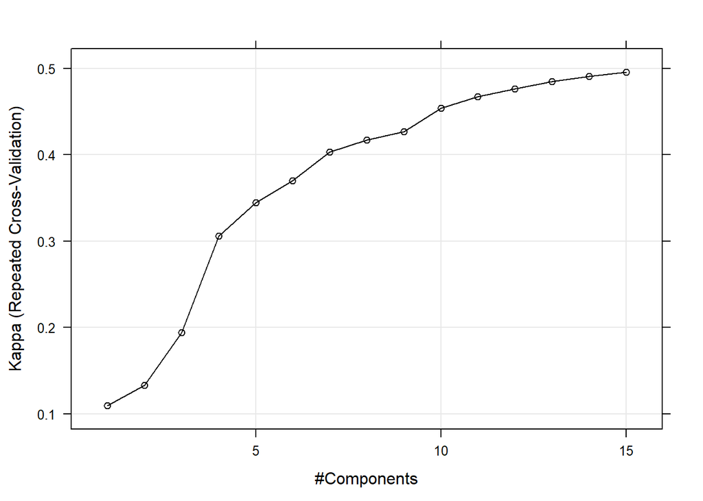

```r
trellis.par.set(caretTheme())
plot(plsFit, metric = "Kappa")
```

```r
confusionMatrix(plsClasses, Test_data$classe)
```

```
## Confusion Matrix and Statistics
##
##           Reference
## Prediction    A    B    C    D    E
##          A 1841  438  367  165  123
##          B   66  676   84  108  230
##          C  145  211  664  123  157
##          D  156   71  184  784  165
##          E   24  122   69  106  767
##
## Overall Statistics
##
##                Accuracy : 0.6031
##                  95% CI : (0.5922, 0.614)
##     No Information Rate : 0.2845
##     P-Value [Acc > NIR] : < 2.2e-16
##
##                   Kappa : 0.4926
##
##  Mcnemar's Test P-Value : < 2.2e-16
##
## Statistics by Class:
##
##                      Class: A Class: B Class: C Class: D Class: E
## Sensitivity            0.8248  0.44532  0.48538  0.60964  0.53190
## Specificity            0.8053  0.92288  0.90182  0.91220  0.94988
## Pos Pred Value         0.6275  0.58076  0.51077  0.57647  0.70496
## Neg Pred Value         0.9204  0.87399  0.89245  0.92260  0.90012
## Prevalence             0.2845  0.19347  0.17436  0.16391  0.18379
## Detection Rate         0.2346  0.08616  0.08463  0.09992  0.09776
## Detection Prevalence   0.3739  0.14836  0.16569  0.17334  0.13867
## Balanced Accuracy      0.8151  0.68410  0.69360  0.76092  0.74089
```

I can apply another model like the “regularized discriminant analysis” model

```r
set.seed(123)
rdaFit <- train(classe ~ ., data = Train_data, method = "rda", tuneGrid = data.frame(gamma = (0:4)/4, lambda = 3/4), trControl = ctrl, metric = "ROC")
rdaFit
```

```
## Regularized Discriminant Analysis
##
## 11776 samples
##    52 predictor
##     5 classes: 'A', 'B', 'C', 'D', 'E'
##
## No pre-processing
## Resampling: Cross-Validated (10 fold, repeated 3 times)
## Summary of sample sizes: 10599, 10597, 10599, 10597, 10598, 10600, ...
## Resampling results across tuning parameters:
##
##   gamma  Accuracy   Kappa
##   0.00   0.8303888  0.7861670
##   0.25   0.5906087  0.4842188
##   0.50   0.5270047  0.4034536
##   0.75   0.4794245  0.3422198
##   1.00   0.3982672  0.2342513
##
## Tuning parameter 'lambda' was held constant at a value of 0.75
## Accuracy was used to select the optimal model using the largest value.
## The final values used for the model were gamma = 0 and lambda = 0.75.
```

```r
rdaClasses <- predict(rdaFit, newdata = Test_data)
confusionMatrix(rdaClasses, Test_data$classe)
```

```
## Confusion Matrix and Statistics
##
##           Reference
## Prediction    A    B    C    D    E
##          A 1911  161   11    5   14
##          B   33 1113   92    5   73
##          C  166  191 1239  213  100
##          D  119   39   22 1051   72
##          E    3   14    4   12 1183
##
## Overall Statistics
##
##                Accuracy : 0.8281
##                  95% CI : (0.8195, 0.8364)
##     No Information Rate : 0.2845
##     P-Value [Acc > NIR] : < 2.2e-16
##
##                   Kappa : 0.7832
##
##  Mcnemar's Test P-Value : < 2.2e-16
##
## Statistics by Class:
##
##                      Class: A Class: B Class: C Class: D Class: E
## Sensitivity            0.8562   0.7332   0.9057   0.8173   0.8204
## Specificity            0.9660   0.9679   0.8966   0.9616   0.9948
## Pos Pred Value         0.9091   0.8457   0.6490   0.8066   0.9729
## Neg Pred Value         0.9441   0.9380   0.9783   0.9641   0.9609
## Prevalence             0.2845   0.1935   0.1744   0.1639   0.1838
## Detection Rate         0.2436   0.1419   0.1579   0.1340   0.1508
## Detection Prevalence   0.2679   0.1677   0.2433   0.1661   0.1550
## Balanced Accuracy      0.9111   0.8506   0.9011   0.8894   0.9076
```

and see how these two models (pls, rda) compare in terms of their resampling results.

```r
resamps <- resamples(list(pls = plsFit, rda = rdaFit))
summary(resamps)
```

```
##
## Call:
## summary.resamples(object = resamps)
##
## Models: pls, rda
## Number of resamples: 30
##
## Accuracy
##         Min.   1st Qu.    Median      Mean   3rd Qu.      Max. NA's
## pls 0.581849 0.5946927 0.6048387 0.6054425 0.6121973 0.6363636    0
## rda 0.811545 0.8222175 0.8306452 0.8303888 0.8379639 0.8524173    0
##
## Kappa
##          Min.   1st Qu.    Median      Mean   3rd Qu.      Max. NA's
## pls 0.4666544 0.4821540 0.4955596 0.4959794 0.5051605 0.5368063    0
## rda 0.7627775 0.7757157 0.7863579 0.7861670 0.7956972 0.8137322    0
```

```r
diffs <- diff(resamps)
summary(diffs)
```

```
##
## Call:
## summary.diff.resamples(object = diffs)
##
## p-value adjustment: bonferroni
## Upper diagonal: estimates of the difference
## Lower diagonal: p-value for H0: difference = 0
##
## Accuracy
##     pls       rda
## pls           -0.2249
## rda < 2.2e-16
##
## Kappa
##     pls       rda
## pls           -0.2902
## rda < 2.2e-16
```

And then a plot to visualise the result

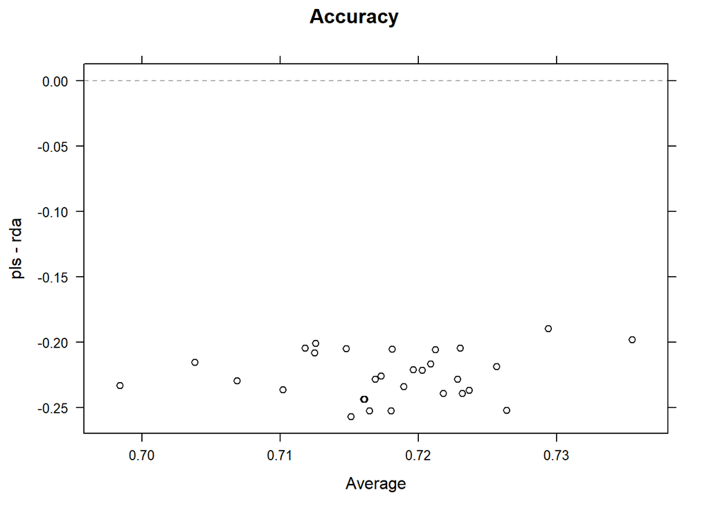

```r
xyplot(resamps, what = "BlandAltman")
```

I can now also try the “Random Forest” model:

```r
rfFit <- train(classe~., data=Train_data, method="rf", tuneGrid=expand.grid(.mtry=sqrt(ncol(Train_data[,2:53]))), trControl=ctrl)
rfFit
```

```
## Random Forest
##
## 11776 samples
##    52 predictor
##     5 classes: 'A', 'B', 'C', 'D', 'E'
##
## No pre-processing
## Resampling: Cross-Validated (10 fold, repeated 3 times)
## Summary of sample sizes: 10599, 10598, 10598, 10600, 10598, 10597, ...
## Resampling results:
##
##   Accuracy   Kappa
##   0.9925839  0.9906191
##
## Tuning parameter 'mtry' was held constant at a value of 7.211103
```

```r
rfClasses <- predict(rfFit, newdata = Test_data)
confusionMatrix(rfClasses, Test_data$classe)
```

```
## Confusion Matrix and Statistics
##
##           Reference
## Prediction    A    B    C    D    E
##          A 2230    3    0    0    0
##          B    2 1510    6    0    0
##          C    0    5 1362   30    3
##          D    0    0    0 1255    3
##          E    0    0    0    1 1436
##
## Overall Statistics
##
##                Accuracy : 0.9932
##                  95% CI : (0.9912, 0.9949)
##     No Information Rate : 0.2845
##     P-Value [Acc > NIR] : < 2.2e-16
##
##                   Kappa : 0.9915
##
##  Mcnemar's Test P-Value : NA
##
## Statistics by Class:
##
##                      Class: A Class: B Class: C Class: D Class: E
## Sensitivity            0.9991   0.9947   0.9956   0.9759   0.9958
## Specificity            0.9995   0.9987   0.9941   0.9995   0.9998
## Pos Pred Value         0.9987   0.9947   0.9729   0.9976   0.9993
## Neg Pred Value         0.9996   0.9987   0.9991   0.9953   0.9991
## Prevalence             0.2845   0.1935   0.1744   0.1639   0.1838
## Detection Rate         0.2842   0.1925   0.1736   0.1600   0.1830
## Detection Prevalence   0.2846   0.1935   0.1784   0.1603   0.1832
## Balanced Accuracy      0.9993   0.9967   0.9949   0.9877   0.9978
```

```r
varImp(rfFit)
```

```
## rf variable importance
##
##   only 20 most important variables shown (out of 52)
##
##                      Overall
## roll_belt             100.00
## yaw_belt               67.11
## magnet_dumbbell_z      60.36
## pitch_forearm          56.98
## magnet_dumbbell_y      53.47
## pitch_belt             53.08
## roll_forearm           47.55
## magnet_dumbbell_x      35.15
## accel_dumbbell_y       32.01
## roll_dumbbell          31.18
## magnet_belt_y          28.78
## accel_belt_z           28.49
## magnet_belt_z          28.37
## accel_dumbbell_z       23.04
## roll_arm               22.99
## gyros_belt_z           22.76
## accel_forearm_x        21.86
## magnet_forearm_z       19.03
## total_accel_dumbbell   17.75
## yaw_dumbbell           17.67
```

```r
rfFit$finalModel
```

```
##
## Call:
##  randomForest(x = x, y = y, mtry = param$mtry)
##                Type of random forest: classification
##                      Number of trees: 500
## No. of variables tried at each split: 7
##
##         OOB estimate of  error rate: 0.59%
## Confusion matrix:
##      A    B    C    D    E class.error
## A 3342    4    1    0    1 0.001792115
## B   10 2260    9    0    0 0.008336990
## C    0    8 2042    4    0 0.005842259
## D    0    0   24 1904    2 0.013471503
## E    0    0    2    5 2158 0.003233256
```

## Conclusion

Now I can try to use this model on my original tasting batch of data and so:

```r
TestResult <- predict(rfFit, newdata=TestingData)
TestResult
```

```
##  [1] B A B A A E D B A A B C B A E E A B B B
## Levels: A B C D E
```